# R Notebook

# 統計學習初論（106-2）作業六 第二題

# (1)

Load libraries and data

```r
library(ggplot2)
library(reshape2)
library(gridExtra)
library(glmnet)
library(randomForest)
library(e1071)
load('data/50kpred.rdata')
df_train_all <- raw1
df_test <- raw_test
df_all <- rbind(df_train_all, df_test)
```

```r
plotPorpotion <- function(df, feature){

    occupation_above = data.frame(table(df[df[,"y_income" ] == TRUE,]$occupation))
    occupation_below = data.frame(table(df[df[,"y_income" ] == FALSE,]$occupation))
    occupation_all = data.frame(table(df[df[,"y_income" ] == FALSE,]$occupation))
    occupation = merge(x = occupation_above, y = occupation_below, by = "Var1")
    occu_names = c('occupation', 'above', 'below')
    colnames(occupation) = occu_names
    occupation$above_proportion = occupation$above/ (occupation$above + occupation$below)
    ggplot(occupation, aes(x=occupation, y=above_proportion, ), xlab="Gender", ylab="Counts") +
        geom_bar(stat="identity", fill="lightgreen", color="grey50") +
        theme(axis.text.x = element_text(angle = 45, hjust = 1))+
        ggtitle('Proportions of above 50k with different occupation')+
          xlab("occupation") +
          ylab("proportion")
}
table(df_all$y_income)
```

```
FALSE  TRUE
34014 11208
```

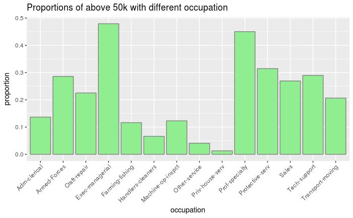

```r
plotPorpotion(df_all, 'occupation')
```

首先我們透過 `table(df_all$y_income)` 觀察到，這個資料集約75%的資料income都是<50k的

我們選擇 occupation 這個 key variable來作圖，觀察到最高的兩種職業為 Exec-managerial和 Prof-specialty，皆接近50%

可以明顯看出管理階層和具有專業的職業，都有顯著較高的收入

再來最低的幾個 Priv-house-serv , Other-service , Handlers-cleaners 多為服務和清潔類型，也符合我們傳統上認為這幾種行業收入偏低的印象

# 2

Filter features and one-hot-encoding

```r
standarize <- function(x_train, x_test){
    x_train_mean = t(apply(x_train, 2, function(x) mean(x, na.rm=TRUE)))
    x_train_sd = apply(x_train, 2, function(x) sd(x, na.rm=TRUE))
    x_train_new = sweep(x_train, 2, x_train_mean)
    x_train_new = sweep(x_train_new, MARGIN=2, x_train_sd,`/`)
    x_test_new = sweep(x_test, 2, x_train_mean)
    x_test_new = sweep(x_test_new, MARGIN=2, x_train_sd,`/`)
    return(list(x_train = x_train_new, x_test = x_test_new))
}
getFeatureClasses <- function(df, dum_features){
    result = list()
    i <- 1
    for(feat in dum_features){
        cl =  as.vector(data.frame(table(df[,feat]))[table(df[,feat]) > 50,1])
        result[[feat]] = cl
        i <- i + 1
    }
    return(result)
}

cbind.fill<-function(...){
  nm <- list(...)
  nm<-lapply(nm, as.matrix)
  n <- max(sapply(nm, nrow))
  as.data.frame(do.call(cbind, lapply(nm, function (x)
    rbind(x, matrix(, n-nrow(x), ncol(x))))))
}
onehotencoding <- function(dum_features, dum_classes, df){
    df = df[,dum_features]
    for(feature in dum_features){
        classes = dum_classes[feature]
        for(c in classes){
            dummy <- as.numeric(df[feature] == c)
            dum_class_name = paste(feature, c, sep="_")
            df[dum_class_name] = dummy
        }
    }
    return(df[ , !(names(df) %in% dum_features)])
}
dum_features = c("workclass", "marital_status", "occupation","relationship", "race", "sex", "native_country")
dum_classes = getFeatureClasses(df_all, dum_features)
df_train_all_dummy = onehotencoding(dum_features, dum_classes, df_train_all)
df_test_dummy = onehotencoding(dum_features, dum_classes, df_test)
continuous_features = c("age", "fnlwgt", "education_num", "capital_gain", "capital_loss", "hours_per_week")
df_train_all_cont = df_train_all[,continuous_features]
df_test_cont = df_test[,continuous_features]
df_train_all_cont_std = standarize(df_train_all_cont, df_test_cont)$x_train
df_test_cont_std = standarize(df_train_all_cont, df_test_cont)$x_test
df_train_all_x = cbind.fill(df_train_all_cont_std,df_train_all_dummy)
df_train_all_y = df_train_all$y_income
df_tune_x <- df_train_all_x[folds == 10,]
df_tune_y <- df_train_all[folds == 10,]$y_income
df_train_x <- df_train_all_x[folds!= 10, ]
df_train_y <- df_train_all[folds != 10,]$y_income
df_test_x = cbind.fill(df_test_cont_std,df_test_dummy)
df_test_y = df_test$y_income
```

Training and tuning ridge regression model

```r
alpha = c(1, 0.1, 0.001, 0.0001,  0)
err_list = c()
for(a in alpha){
    fit <- glmnet(as.matrix(df_train_x), df_train_y, alpha = a, family="binomial")
    x_predict_result = predict(fit, as.matrix(df_tune_x), s = 0.0001, type = "response") >= 0.5
    err = 1 - sum((df_tune_y == x_predict_result) == TRUE) / length(x_predict_result)
    err_list = c(err_list,err)
}
data.frame(alpha = alpha, error_rate = err_list)
```

| alpha | error_rate |
| --- | --- |
| 1e+00 | 0.1771080 |
| 1e-01 | 0.1771080 |
| 1e-03 | 0.1815103 |
| 1e-04 | 0.1815103 |
| 0e+00 | 0.1815103 |

Fine tune alpha的值，其為1 或0.1時有最好的表現

有此可以推測可能在使用 alpha=1 lasso penalty 會比 alpha=0 ridge penalty 有好的結果

```r
regression_model <- glmnet(as.matrix(df_train_all_x), df_train_all_y, alpha = 1, family="binomial")
x_predict_result = predict(regression_model, as.matrix(df_test_x), s = 0.0001, type = "response") >= 0.5
err_regression_model = 1-sum((df_test_y == x_predict_result) == TRUE) / length(x_predict_result)
err_regression_model
```

```
[1] 0.1934927
```

testing error rate 為 0.1934927

# 3

```r
randomForestTuning <- function(df_train_x, df_train_y, df_tune_x, df_tune_y,  df_train_all_x, df_train_all_y, df_test_x, df_test_y, grid_length = 20,  grid_type = "equal", rfntree = 50 ,debuglevel=0){
    errtest <- function (test){
        acc = sum (((test$pred >= 0.5) == df_tune_y) == TRUE) / length(df_tune_y)
        return(1 - acc)
    }
    ncol = dim(df_train_x)[2]
    m_min = 2
    m_max = ncol
    grids = NULL
    if(grid_type == "loglinear"){
        grids = unique(round(exp(seq(log(m_min), log(m_max),length=grid_length))))
    }
    else if(grid_type == 'equal'){
        grids = unique(round(seq(m_min, m_max, length=grid_length )))
    }

    best_mtry = 2
    best_err = 1000
    err_list = c()
    best_rf = NULL
    for(mtry in grids){
        result = randomForest(x = df_train_x, y = df_train_y, xtest=df_tune_x,ytest= df_tune_y, ntree = rfntree ,mtry = mtry)
        test_err = errtest(result$test)
        err_list = c(err_list, test_err)
        print(test_err)
        if(test_err  < best_err){
            best_err = test_err
            best_mtry = mtry
            best_rf = result
        }else{
            break;
        }
    }
    return(list(best_mtry = best_mtry, mtrys = mtrys,err_list = err_list, test_err = test_err, best_rf = best_rf))
}


rf = randomForestTuning(df_train_x, df_train_y, df_tune_x, df_tune_y,  df_train_all_x, df_train_all_y, df_test_x, df_test_y)
```

以上為fine tune random forest的程式碼，由於執行時間相當的長，以下只呈現最後結果，使用 ntree = 100 ,mtry = 11

```r
rf = randomForest(x = df_train_x, y = df_train_y, xtest=df_test_x, ntree = 100 ,mtry = 11,  keep.forest=TRUE)
```

```
The response has five or fewer unique values.  Are you sure you want to do regression?
```

```r
errtest <- function (test){
    acc = sum (((test$pred >= 0.5) == df_test_y) == TRUE) / length(df_test_y)
    return(1 - acc)
}
```

```r
predict_rf = predict(rf, newdata=df_test_x)
error_rf = 1 - sum (((predict_rf >= 0.5) == df_test_y) == TRUE) / length(df_test_y)
error_rf
```

```
[1] 0.1718459
```

testing error rate 為 0.1718459，比ridge regression model要好一些

# 4

```r
costs = c(20, 10, 1)
err_list = c()
best_svm_model = NULL
best_err = 1000
for(c in costs){
  svm_model = svm(as.matrix(df_train_x), as.matrix(df_train_y), type = "C", cost = c, probability = TRUE)
  predict = predict(svm_model, newdata = as.matrix(df_tune_x))
  error_rate = 1 - sum((df_tune_y == predict) == TRUE) / length(df_tune_y)
  if(error_rate < best_err){
    best_err = error_rate
    best_svm_model = svm_model
  }
  print(error_rate)
  err_list = c(err_list, error_rate)
}
```

```
[1] 0.181849
[1] 0.1815103
[1] 0.1879445
```

```r
data.frame(costs = costs, error_rate = err_list)
```

| costs | error_rate |
| --- | --- |
| 20 | 0.1818490 |
| 10 | 0.1815103 |
| 1 | 0.1879445 |

```r
predict = predict(best_svm_model, newdata = as.matrix(df_test_x), probability = TRUE)
error_rate = 1 - sum((df_test_y == predict) == TRUE) / length(df_test_y)
error_rate
```

```
[1] 0.1891766
```

對cost fine tune的結果得到的error rate為 0.1891766，為三者中第二好的結果

# 5

```r
# Get predict result
predict_regression = predict(regression_model, as.matrix(df_test_x), s = 0.0001, type = "response")
predict_rf = predict(rf, newdata=df_test_x)
predict_svm = attr(predict(best_svm_model, newdata = as.matrix(df_test_x), probability = TRUE), "prob")[,1]
```

以下將對不同的stacking models 做測試

### Simple average of output probabilities

```r
# Simple average of output probabilities
predict_average = (predict_regression + predict_rf + predict_svm) / 3
error_stack_avg = 1 - sum (((predict_average >= 0.5) == df_test_y) == TRUE) / length(df_test_y)
error_stack_avg
```

```
[1] 0.188911
```

### Majority votes

```r
# Majority votes
vote_regression = predict_regression >= 0.5
vote_rf = predict_rf >= 0.5
vote_svm = predict_svm >= 0.5
vote_df = data.frame(vote_regression, vote_rf, vote_svm)
vote_result = c()
for(i in 1:nrow(vote_df)){
  count = 0
  for(j in 1:3){
    if(vote_df[i,j] == TRUE){
      count = count + 1
    }
  }
  if(count >= 2){
    vote_result= c(vote_result, TRUE)
  }
  else{
     vote_result= c(vote_result, FALSE)
  }
}
error_stack_vote = 1 - sum ((vote_result== df_test_y) == TRUE) / length(df_test_y)
error_stack_vote
```

```
[1] 0.1832005
```

### Ridge regression

```r
# Ridge regression
predict_regression_t = predict(regression_model, as.matrix(df_train_all_x), s = 0.0001, type = "response")
predict_rf_t = predict(rf, newdata=df_train_all_x)
predict_svm_t = attr(predict(best_svm_model, newdata = as.matrix(df_train_all_x), probability = TRUE), "prob")[,1]
stack_x_train = data.frame(predict_regression_t, predict_rf_t, predict_svm_t)
stack_regression_model <- glmnet(as.matrix(stack_x_train), df_train_all_y, alpha = 1, family="binomial")
stack_x_test = data.frame(predict_regression, predict_rf, predict_svm)
x_predict_result = predict(stack_regression_model, as.matrix(stack_x_test), s = 0.0001, type = "response") >= 0.5
error_stack_regression = 1-sum((df_test_y == x_predict_result) == TRUE) / length(x_predict_result)
error_stack_regression
```

```
[1] 0.1886454
```

### Comparison

```r
list(ridge_regression = err_regression_model, randomforest = error_rf, svm =  error_rate, stack_avg =error_stack_avg, stack_vote = error_stack_vote, stack_regression = error_stack_regression)
```

```
$ridge_regression
[1] 0.1934927

$randomforest
[1] 0.1718459

$svm
[1] 0.1891766

$stack_avg
[1] 0.188911

$stack_vote
[1] 0.1832005

$stack_regression
[1] 0.1886454
```

Stacking models中，表現最優秀的為major voting

可以有效的避免極端值得狀況，（例如兩個model output為0.3,0.3,一個model output為1，若使用average反而會變成預測TRUE)，並採用最多數的結果

比較stacking models和前面的結果，可以看出他做出來的error rate都介於最好的randomforest和最差的ridge_regression之間，且只輸給randomforest